# 20221222_Walmart_Project_pratham

```python
# !pip install matplotlib --upgrade
```

**Note:**

- Upgrade the matplotlib version form 3.2.2 to 3.5.3
  - Use command

    ```
    !pip install matplotlib --upgrade
    ```

- Restart the session

# 1. Defining Problem Statement and Analysing basic metrics (10 Points)

# 2. Missing Value & Outlier Detection (10 Points)

# 3. Non-Graphical Analysis: Value counts and unique attributes (10 Points)

**About Walmart**

Walmart is an American multinational retail corporation that operates a chain of supercenters, discount departmental stores, and grocery stores from the United States. Walmart has more than 100 million customers worldwide.

**Business Problem**

The management team at Walmart Inc. wants to analyze customer buying patterns (especially purchase amount ) in relation to customer gender and several other factors to help the company make better decisions. They want to find out if the buying habits of male and female customers differ, and for other factors as well.

**Dataset**

The company collected transaction data of customers who purchased products at Walmart stores during Black Friday. The data includes transaction characteristics such as product ID, product category, user information such as user ID, gender, age, occupation, marital status, city category where the user is currently located, length of stay in the current city, and the most important total purchase amount per transaction.

**Analysis Approach and Assumptions**

The data collected does not represent Walmart's entire 100 million customers. The data collected during the Black Friday sales is a sample of all Walmart customers spending pattern. The management team is more interested in understanding the spending behaviour of all customers, not just those who shopped on Black Friday. As directed by the team, we assume that 50 million customers are male and 50 million are female

We will use the Central Limit Theorem to calculate the average spending range with respect to each customer characteristic. Generally the confidence levels 90%, 95%, and 99% are used depending on the business need or criticality of the business problem. The confidence level requirements are not available to us. We will use a 95% confidence level for this analysis, as it is the most commonly used for this type of business problem.

In addition, we will use the bootstrapping approach since we do not have the population variance or the standard deviation of the spending patterns with respect to the various factors. The larger the sample size, the more precise are the results. We will use the number of records we have for a category as the sample size, so we will use the maximum possible sample size. We vary the number of such samples from 10,000 to 1,000 and 100 and observe the results for a parameter. If the results are not very different, we will use 1,000 samples to achieve maximum precision with minimum time and computational efforts.

Finally, we will understand the patterns in the data and the estimated population parameters; then extract the insights and make business recommendations.

**We will carry out the following steps:**

- Observe shape of the data, the data types of all attributes
- Data cleansing, missing value detection, outlier checking, statistical summarization
- Conversion of data types
- Non-graphical analysis: value counts and unique attributes
- Calculation of CI's by bootstrapping
- Visual analysis - univariate and bivariate analysis using distplot, countplot, histogram, boxplot and heatmaps
- Understanding patterns and preferences
- Generating insights and business recommendations

## Download the dataset and observe a subset of the data

**Importing Required Libraries**

```python
# !pip install matplotlib==3.6.2
import numpy as np
import pandas as pd
import matplotlib
import matplotlib.pyplot as plt
from matplotlib.ticker import (MultipleLocator, AutoMinorLocator)
import seaborn as sns
import textwrap
import math
from scipy.stats import norm
```

**Download the Walmart DataSet**

```python
!gdown https://d2beiqkhq929f0.cloudfront.net/public_assets/assets/000/001/293/original/walmart_data.csv?1641285094 -O walmart_data.csv
```

```
Downloading...
From: https://d2beiqkhq929f0.cloudfront.net/public_assets/assets/000/001/293/original/walmart_data.csv?1641285094
To: /content/walmart_data.csv
100% 23.0M/23.0M [00:00<00:00, 219MB/s]
```

```python
df = pd.read_csv('walmart_data.csv')
df.head()
```

|  | User_ID | Product_ID | Gender | Age | Occupation | City_Category | Stay_In_Current_City_Years | Marital_Status | Product_Category | Purchase |
| --- | --- | --- | --- | --- | --- | --- | --- | --- | --- | --- |
| 0 | 1000001 | P00069042 | F | 0-17 | 10 | A | 2 | 0 | 3 | 8370 |
| 1 | 1000001 | P00248942 | F | 0-17 | 10 | A | 2 | 0 | 1 | 15200 |
| 2 | 1000001 | P00087842 | F | 0-17 | 10 | A | 2 | 0 | 12 | 1422 |
| 3 | 1000001 | P00085442 | F | 0-17 | 10 | A | 2 | 0 | 12 | 1057 |
| 4 | 1000002 | P00285442 | M | 55+ | 16 | C | 4+ | 0 | 8 | 7969 |

Custom function to get Discriptive Summary of the Dataset

```python
def get_df_summary(df_, print_summary=True, properties_as_columns=True):
  # Shape and memory usage of DataFrame
  print(f'RangeIndex: {df_.shape[0]} entries; Data columns (total {df_.shape[1]} columns)')
  memory_used = df_.memory_usage().sum()/1024
  if memory_used > 1024*1024:
    memory_used =  f'{round(memory_used/1024/1024, 1)}+ GB'
  elif memory_used > 1024:
    memory_used =  f'{round(memory_used/1024, 1)}+ MB'
  else:
    memory_used =  f'{round(memory_used, 1)}+ KB'
  print(f'memory usage: {memory_used}\n')

  # Create an empty df with column names from original df
  df2 = pd.DataFrame(columns=[None]+df_.columns.to_list())

  # Add dtype
  property_ = ['dtype']
  for clm in df_.columns:
    property_.append(df_[clm].dtype)
  df2 = df2.append(pd.DataFrame([property_], columns=df2.columns))

  # Add Missing Values Counts
  property_ = ['Missing Counts']
  for clm in df_.columns:
    property_.append(df_[clm].isna().sum())
  df2 = df2.append(pd.DataFrame([property_], columns=df2.columns))

  # Add nUniques
  property_ = ['nUniques']
  for clm in df_.columns:
    property_.append(df_[clm].nunique())
  df2 = df2.append(pd.DataFrame([property_], columns=df2.columns))

  # Add unique values
  property_ = ['Top 10 Unique Values']
  for clm in df_.columns:
    df1 = df_[clm].value_counts().reset_index()
    df1['margin'] = df1[clm]*100/ df1[clm].sum()
    property_.append(', '.join([i for i in df1.apply(lambda x:f"{x['index']} ({math.floor(x['margin'])}%)", axis=1).iloc[:10]]))
  df2 = df2.append(pd.DataFrame([property_], columns=df2.columns))

  # Getting Numeric Variables Statistics
  df4 = pd.DataFrame(columns=df_.columns.to_list())
  df4 = df4.append(df_.describe()).drop('count').rename({
      '25%': 'Q1',
      '50%': 'Median',
      '75%': 'Q3'
  }).reset_index().set_index('index').round(1)
  df4 = df4.T
  df4['LW (1.5)'] = df4.apply(lambda x: max(x['min'], x['Q1'] - 1.5*(x['Q3']-x['Q1'])), axis=1)
  df4['UW (1.5)'] = df4.apply(lambda x: min(x['max'], x['Q3'] + 1.5*(x['Q3']-x['Q1'])), axis=1)

  df4['mean-3*std'] = df4.apply(lambda x: max(x['min'], x['mean'] - 3*x['std']), axis=1)
  df4['mean+3*std'] = df4.apply(lambda x: min(x['max'], x['mean'] + 3*x['std']), axis=1)

  lst_IQR_Outlier = []
  lst_std_Outlier = []
  for clm in df4.index:
    if clm in df_.describe().columns:
      iqr_outlier_count = df_.loc[(df_[clm]<df4.loc[clm,'LW (1.5)']) | (df_[clm]>df4.loc[clm,'UW (1.5)'])].shape[0]
      iqr_outlier_pct = f'({round(iqr_outlier_count * 100.0 / df_.__len__(), 1)}%)' if iqr_outlier_count != 0 else ''

      std_outlier_count = df_.loc[(df_[clm]<df4.loc[clm,'mean-3*std']) | (df_[clm]>df4.loc[clm,'mean+3*std'])].shape[0]
      std_outlier_pct = f'({round(std_outlier_count * 100.0 / df_.__len__(), 1)}%)' if std_outlier_count != 0 else ''

      lst_IQR_Outlier.append(f'{iqr_outlier_count} {iqr_outlier_pct}')
      lst_std_Outlier.append(f'{std_outlier_count} {std_outlier_pct}')
    else:
      lst_IQR_Outlier.append(np.nan)
      lst_std_Outlier.append(np.nan)

  df4['Outlier Count (1.5*IQR)'] = lst_IQR_Outlier
  df4['Outlier Count (3*std)'] = lst_std_Outlier

  df4 = df4.round(1).T.reset_index().rename({'index': None}, axis=1)
  df2 = df2.append(df4)

  # Sort the columns acording to dtype
  df2 = df2.set_index(None).T.astype(str).sort_values('dtype', ascending=False)
  df2 = df2[['dtype', 'Missing Counts', 'nUniques', 'Top 10 Unique Values','min','max',
  'LW (1.5)', 'Q1', 'Median', 'Q3',   'UW (1.5)', 'Outlier Count (1.5*IQR)',
  'mean-3*std',  'mean', 'std', 'mean+3*std', 'Outlier Count (3*std)']]

  if not properties_as_columns: df2 = df2.T
  if print_summary: print(df2)

  return df2
```

**Descriptive Summary**

- Observe shape of the data, the data types of all attributes
- Missing value detection, outlier checking, statistical summarization

```python
df_summary = get_df_summary(df, print_summary=False, properties_as_columns=False)
df_summary
```

```
RangeIndex: 550068 entries; Data columns (total 10 columns)
memory usage: 42.0+ MB
```

|  | Product_ID | Gender | Age | City_Category | Stay_In_Current_City_Years | User_ID | Occupation | Marital_Status | Product_Category | Purchase |
| --- | --- | --- | --- | --- | --- | --- | --- | --- | --- | --- |
| dtype | object | object | object | object | object | int64 | int64 | int64 | int64 | int64 |
| Missing Counts | 0 | 0 | 0 | 0 | 0 | 0 | 0 | 0 | 0 | 0 |
| nUniques | 3631 | 2 | 7 | 3 | 5 | 5891 | 21 | 2 | 20 | 18105 |
| Top 10 Unique Values | P00265242 (0%), P00025442 (0%), P00110742 (0%)... | M (75%), F (24%) | 26-35 (39%), 36-45 (19%), 18-25 (18%), 46-50 (... | B (42%), C (31%), A (26%) | 1 (35%), 2 (18%), 3 (17%), 4+ (15%), 0 (13%) | 1001680.0 (0%), 1004277.0 (0%), 1001941.0 (0%)... | 4.0 (13%), 0.0 (12%), 7.0 (10%), 1.0 (8%), 17.... | 0.0 (59%), 1.0 (40%) | 5.0 (27%), 1.0 (25%), 8.0 (20%), 11.0 (4%), 2.... | 7011.0 (0%), 7193.0 (0%), 6855.0 (0%), 6891.0 ... |
| min | nan | nan | nan | nan | nan | 1000001.0 | 0.0 | 0.0 | 1.0 | 12.0 |
| max | nan | nan | nan | nan | nan | 1006040.0 | 20.0 | 1.0 | 20.0 | 23961.0 |
| LW (1.5) | nan | nan | nan | nan | nan | 1000001.0 | 0.0 | 0.0 | 1.0 | 12.0 |
| Q1 | nan | nan | nan | nan | nan | 1001516.0 | 2.0 | 0.0 | 1.0 | 5823.0 |
| Median | nan | nan | nan | nan | nan | 1003077.0 | 7.0 | 0.0 | 5.0 | 8047.0 |
| Q3 | nan | nan | nan | nan | nan | 1004478.0 | 14.0 | 1.0 | 8.0 | 12054.0 |
| UW (1.5) | nan | nan | nan | nan | nan | 1006040.0 | 20.0 | 1.0 | 18.5 | 21400.5 |
| Outlier Count (1.5*IQR) | nan | nan | nan | nan | nan | 0 | 0 | 0 | 4153 (0.8%) | 2677 (0.5%) |
| mean-3*std | nan | nan | nan | nan | nan | 1000001.0 | 0.0 | 0.0 | 1.0 | 12.0 |
| mean | nan | nan | nan | nan | nan | 1003028.8 | 8.1 | 0.4 | 5.4 | 9264.0 |
| std | nan | nan | nan | nan | nan | 1727.6 | 6.5 | 0.5 | 3.9 | 5023.1 |
| mean+3*std | nan | nan | nan | nan | nan | 1006040.0 | 20.0 | 1.0 | 17.1 | 23961.0 |
| Outlier Count (3*std) | nan | nan | nan | nan | nan | 0 | 0 | 0 | 7278 (1.3%) | 0 |

Check categorical variables for outliers

```python
df['Product_Category'].sort_values().unique()
```

```
array([ 1,  2,  3,  4,  5,  6,  7,  8,  9, 10, 11, 12, 13, 14, 15, 16, 17,
       18, 19, 20])
```

```python
df['Age'].sort_values().unique()
```

```
array(['0-17', '18-25', '26-35', '36-45', '46-50', '51-55', '55+'],
      dtype=object)
```

```python
df['Occupation'].sort_values().unique()
```

```
array([ 0,  1,  2,  3,  4,  5,  6,  7,  8,  9, 10, 11, 12, 13, 14, 15, 16,
       17, 18, 19, 20])
```

Convert **Product_ID, Product_Category, User_ID, Gender, Age, Marital_Status, Occupation, City_Category, and Stay_In_Current_City_Years** variable dtypes to Category

This can lead to a reduction in memory requirements and provide performance benefits

```python
for col in ['Product_ID', 'Product_Category', 'User_ID', 'Gender', 'Age', 'Marital_Status', 'Occupation', 'City_Category', 'Stay_In_Current_City_Years']:
  df[col] = df[col].astype('category')
```

**Check potential outliers based on the criteria 1.5*IQR and 3*Std**

```python
df_potiential_outliers = df.loc[(df['Purchase']<float(df_summary.loc['LW (1.5)','Purchase'])) | (df['Purchase']>float(df_summary.loc['UW (1.5)','Purchase']))]
df_potiential_outliers
```

|  | User_ID | Product_ID | Gender | Age | Occupation | City_Category | Stay_In_Current_City_Years | Marital_Status | Product_Category | Purchase |
| --- | --- | --- | --- | --- | --- | --- | --- | --- | --- | --- |
| 343 | 1000058 | P00117642 | M | 26-35 | 2 | B | 3 | 0 | 10 | 23603 |
| 375 | 1000062 | P00119342 | F | 36-45 | 3 | A | 1 | 0 | 10 | 23792 |
| 652 | 1000126 | P00087042 | M | 18-25 | 9 | B | 1 | 0 | 10 | 23233 |
| 736 | 1000139 | P00159542 | F | 26-35 | 20 | C | 2 | 0 | 10 | 23595 |
| 1041 | 1000175 | P00052842 | F | 26-35 | 2 | B | 1 | 0 | 10 | 23341 |
| ... | ... | ... | ... | ... | ... | ... | ... | ... | ... | ... |
| 544488 | 1005815 | P00116142 | M | 26-35 | 20 | B | 1 | 0 | 10 | 23753 |
| 544704 | 1005847 | P00085342 | F | 18-25 | 4 | B | 2 | 0 | 10 | 23724 |
| 544743 | 1005852 | P00202242 | F | 26-35 | 1 | A | 0 | 1 | 10 | 23529 |
| 545663 | 1006002 | P00116142 | M | 51-55 | 0 | C | 1 | 1 | 10 | 23663 |
| 545787 | 1006018 | P00052842 | M | 36-45 | 1 | C | 3 | 0 | 10 | 23496 |

2677 rows × 10 columns

```python
df_potiential_outliers_summary = get_df_summary(df_potiential_outliers, print_summary=False, properties_as_columns=False)
df_potiential_outliers_summary
```

```
RangeIndex: 2677 entries; Data columns (total 10 columns)
memory usage: 405.4+ KB
```

|  | Purchase | User_ID | Product_ID | Gender | Age | Occupation | City_Category | Stay_In_Current_City_Years | Marital_Status | Product_Category |
| --- | --- | --- | --- | --- | --- | --- | --- | --- | --- | --- |
| dtype | int64 | category | category | category | category | category | category | category | category | category |
| Missing Counts | 0 | 0 | 0 | 0 | 0 | 0 | 0 | 0 | 0 | 0 |
| nUniques | 1027 | 1487 | 48 | 2 | 7 | 21 | 3 | 5 | 2 | 3 |
| Top 10 Unique Values | 23282.0 (0%), 23313.0 (0%), 23092.0 (0%), 2326... | 1003635.0 (0%), 1001191.0 (0%), 1001926.0 (0%)... | P00052842 (18%), P00116142 (12%), P00085342 (1... | M (77%), F (22%) | 26-35 (34%), 36-45 (22%), 18-25 (12%), 51-55 (... | 0.0 (12%), 4.0 (10%), 7.0 (9%), 1.0 (9%), 20.0... | B (39%), C (34%), A (25%) | 1 (36%), 3 (17%), 2 (16%), 4+ (15%), 0 (13%) | 0.0 (55%), 1.0 (44%) | 10.0 (84%), 15.0 (12%), 9.0 (2%), 1.0 (0%), 12... |
| min | 21401.0 | nan | nan | nan | nan | nan | nan | nan | nan | nan |
| max | 23961.0 | nan | nan | nan | nan | nan | nan | nan | nan | nan |
| LW (1.5) | 22359.0 | nan | nan | nan | nan | nan | nan | nan | nan | nan |
| Q1 | 23154.0 | nan | nan | nan | nan | nan | nan | nan | nan | nan |
| Median | 23418.0 | nan | nan | nan | nan | nan | nan | nan | nan | nan |
| Q3 | 23684.0 | nan | nan | nan | nan | nan | nan | nan | nan | nan |
| UW (1.5) | 23961.0 | nan | nan | nan | nan | nan | nan | nan | nan | nan |
| Outlier Count (1.5*IQR) | 327 (12.2%) | nan | nan | nan | nan | nan | nan | nan | nan | nan |
| mean-3*std | 21401.0 | nan | nan | nan | nan | nan | nan | nan | nan | nan |
| mean | 23238.4 | nan | nan | nan | nan | nan | nan | nan | nan | nan |
| std | 701.7 | nan | nan | nan | nan | nan | nan | nan | nan | nan |
| mean+3*std | 23961.0 | nan | nan | nan | nan | nan | nan | nan | nan | nan |
| Outlier Count (3*std) | 0 | nan | nan | nan | nan | nan | nan | nan | nan | nan |

```python
df.loc[df['Product_Category'].isin([10, 15, 9])].describe()
```

|  | Purchase |
| --- | --- |
| count | 11825.000000 |
| mean | 16928.259366 |
| std | 5362.895975 |
| min | 4148.000000 |
| 25% | 13051.000000 |
| 50% | 17385.000000 |
| 75% | 21239.000000 |
| max | 23961.000000 |

As observed, the average spending on the product categories 10, 15, and 9 are higher than the overall average. It should be noted that the records that looked like outliers are actual customer data that were not accidentally inserted. Furthermore, the potential outliers represent a very small portion of the data (0.5%), and the variation is not large enough to affect our analysis. Therefore, we decide to keep these outliers for further analysis.

**Create a save point for the cleaned version of dataframe**

```python
df_v01 = df
```

**Rename the old columns and reorder**

```python
df = df.rename({
    'Stay_In_Current_City_Years': 'City_Stay'
}, axis=1)
df = df[['Product_ID', 'Product_Category', 'User_ID', 'Gender', 'Age', 'Marital_Status', 'Occupation', 'City_Category', 'City_Stay', 'Purchase']]
df.head()
```

|  | Product_ID | Product_Category | User_ID | Gender | Age | Marital_Status | Occupation | City_Category | City_Stay | Purchase |
| --- | --- | --- | --- | --- | --- | --- | --- | --- | --- | --- |
| 0 | P00069042 | 3 | 1000001 | F | 0-17 | 0 | 10 | A | 2 | 8370 |
| 1 | P00248942 | 1 | 1000001 | F | 0-17 | 0 | 10 | A | 2 | 15200 |
| 2 | P00087842 | 12 | 1000001 | F | 0-17 | 0 | 10 | A | 2 | 1422 |
| 3 | P00085442 | 12 | 1000001 | F | 0-17 | 0 | 10 | A | 2 | 1057 |
| 4 | P00285442 | 8 | 1000002 | M | 55+ | 0 | 16 | C | 4+ | 7969 |

**Final Discriptive Summary of the Dataset**

```python
df_summary = get_df_summary(df, print_summary=False, properties_as_columns=False)
df_summary
```

```
RangeIndex: 550068 entries; Data columns (total 10 columns)
memory usage: 10.3+ MB
```

|  | Purchase | Product_ID | Product_Category | User_ID | Gender | Age | Marital_Status | Occupation | City_Category | City_Stay |
| --- | --- | --- | --- | --- | --- | --- | --- | --- | --- | --- |
| dtype | int64 | category | category | category | category | category | category | category | category | category |
| Missing Counts | 0 | 0 | 0 | 0 | 0 | 0 | 0 | 0 | 0 | 0 |
| nUniques | 18105 | 3631 | 20 | 5891 | 2 | 7 | 2 | 21 | 3 | 5 |
| Top 10 Unique Values | 7011.0 (0%), 7193.0 (0%), 6855.0 (0%), 6891.0 ... | P00265242 (0%), P00025442 (0%), P00110742 (0%)... | 5.0 (27%), 1.0 (25%), 8.0 (20%), 11.0 (4%), 2.... | 1001680.0 (0%), 1004277.0 (0%), 1001941.0 (0%)... | M (75%), F (24%) | 26-35 (39%), 36-45 (19%), 18-25 (18%), 46-50 (... | 0.0 (59%), 1.0 (40%) | 4.0 (13%), 0.0 (12%), 7.0 (10%), 1.0 (8%), 17.... | B (42%), C (31%), A (26%) | 1 (35%), 2 (18%), 3 (17%), 4+ (15%), 0 (13%) |
| min | 12.0 | nan | nan | nan | nan | nan | nan | nan | nan | nan |
| max | 23961.0 | nan | nan | nan | nan | nan | nan | nan | nan | nan |
| LW (1.5) | 12.0 | nan | nan | nan | nan | nan | nan | nan | nan | nan |
| Q1 | 5823.0 | nan | nan | nan | nan | nan | nan | nan | nan | nan |
| Median | 8047.0 | nan | nan | nan | nan | nan | nan | nan | nan | nan |
| Q3 | 12054.0 | nan | nan | nan | nan | nan | nan | nan | nan | nan |
| UW (1.5) | 21400.5 | nan | nan | nan | nan | nan | nan | nan | nan | nan |
| Outlier Count (1.5*IQR) | 2677 (0.5%) | nan | nan | nan | nan | nan | nan | nan | nan | nan |
| mean-3*std | 12.0 | nan | nan | nan | nan | nan | nan | nan | nan | nan |
| mean | 9264.0 | nan | nan | nan | nan | nan | nan | nan | nan | nan |
| std | 5023.1 | nan | nan | nan | nan | nan | nan | nan | nan | nan |
| mean+3*std | 23961.0 | nan | nan | nan | nan | nan | nan | nan | nan | nan |
| Outlier Count (3*std) | 0 | nan | nan | nan | nan | nan | nan | nan | nan | nan |

# 3. Business Insights based on Non-Graphical and Visual Analysis (10 Points)

# 4. Answering questions (50 Points)

# 5. Final Insights (10 Points)

# 6. Recommendations (10 Points)

## Custom functions to plot custom charts and tables

```python
def plot_hist_custom(ax_, df_, var_, title_, scale_x_major, scale_x_minor, color_='#DC3535'):
  if pd.api.types.is_datetime64_any_dtype(df_[var_]):
    df_[var_] = df_[var_].dt.year

  m1 = df_[var_].mean()
  st1 = df_[var_].std()

  q1 = df_[var_].quantile(.25)
  q2 = df_[var_].median()
  q3 = df_[var_].quantile(.75)

  sns.histplot(data=df_, x=var_, kde=True,
               binwidth=scale_x_minor,
               color=color_, ax=ax_, linewidth=2)
  df_mean = pd.DataFrame({'x': [m1, m1], 'y': ax_.get_ybound()})
  df_q1 = pd.DataFrame({'x': [q1, q1], 'y': ax_.get_ybound()})
  df_q2 = pd.DataFrame({'x': [q2, q2], 'y': ax_.get_ybound()})
  df_q3 = pd.DataFrame({'x': [q3, q3], 'y': ax_.get_ybound()})
  sns.lineplot(data=df_mean, x='x', y='y', color='red', ax=ax_, linestyle='--',
              estimator=None, linewidth = 2)
  sns.lineplot(data=df_q1, x='x', y='y', color='black', ax=ax_, linestyle='--',
              estimator=None, linewidth = 1)
  sns.lineplot(data=df_q2, x='x', y='y', color='cyan', ax=ax_, linestyle='--',
              estimator=None, linewidth = 2)
  sns.lineplot(data=df_q3, x='x', y='y', color='black', ax=ax_, linestyle='--',
              estimator=None, linewidth = 1)

  plt.sca(ax_)
  plt.title(title_, size=16, color='grey')
  plt.tick_params(
        axis='x',          # changes apply to the x-axis
        which='both',      # both major and minor ticks are affected
        bottom=False,      # ticks along the bottom edge are off
        top=False,         # ticks along the top edge are off
        labelbottom=False) # labels along the bottom edge are off
  plt.xlabel('')
  plt.ylabel('Count', size=12)
  plt.yticks(size=12)
  sns.despine(bottom=True, left=False, trim=True, ax=ax_)
  ax_.spines['left'].set_color('grey')

  ax_.xaxis.set_major_locator(MultipleLocator(scale_x_major))
  ax_.xaxis.set_major_formatter('{x:.0f}')
  ax_.xaxis.set_minor_locator(MultipleLocator(scale_x_minor))

  ax_.figure.set_size_inches(16,11)
  plt.subplots_adjust(top=0.95, right=0.869, hspace=0, wspace=0.1)

  return plt
```

```python
def plot_box_custom(ax_, df_, var_, xlabel_, scale_x_major, scale_x_minor, color_='#DC3535'):
  if pd.api.types.is_datetime64_any_dtype(df_[var_]):
    df_[var_] = df_[var_].dt.year

  m1 = df_[var_].mean()
  st1 = df_[var_].std()

  q1 = df_[var_].quantile(.25)
  q2 = df_[var_].median()
  q3 = df_[var_].quantile(.75)

  df_mean = pd.DataFrame({'x': [m1, m1], 'y': ax_.get_ybound()})
  df_q1 = pd.DataFrame({'x': [q1, q1], 'y': ax_.get_ybound()})
  df_q2 = pd.DataFrame({'x': [q2, q2], 'y': ax_.get_ybound()})
  df_q3 = pd.DataFrame({'x': [q3, q3], 'y': ax_.get_ybound()})

  df_mean['y'] = [-0.3, 0.2]
  df_q1['y'] = [0.2, 0.25]
  df_q2['y'] = [0.1, 0.25]
  df_q3['y'] = [0.2, 0.25]

  sns.boxplot(data=df_, x=var_, ax=ax_,
                    color=color_, showmeans=True,
                    flierprops={"marker": "x"}, medianprops={"color": "cyan"},
                    width=0.4, fliersize=1, linewidth=2, notch=True)
  sns.lineplot(data=df_mean, x='x', y='y', color='red', ax=ax_, linestyle='--',
              estimator=None, linewidth = 2)
  text = f' μ={m1:.1f}\n σ={st1:.1f}'
  ax_.annotate(text, xy=(m1, -0.3), rotation=90)

  sns.lineplot(data=df_q1, x='x', y='y', color='black', ax=ax_, linestyle='--',
              estimator=None, linewidth = 1)
  text = f'Q1={q1:.1f} '
  ax_.annotate(text, xy=(q1-0.1, 0.25), rotation=90, va='top', ha='right')
  sns.lineplot(data=df_q2, x='x', y='y', color='cyan', ax=ax_, linestyle='--',
              estimator=None, linewidth = 2)
  text = f'med={q2:.1f} '
  ax_.annotate(text, xy=(q2, 0.25), rotation=90, va='top', ha='center')
  sns.lineplot(data=df_q3, x='x', y='y', color='black', ax=ax_, linestyle='--',
              estimator=None, linewidth = 1)
  text = f'Q3={q3:.1f} '
  ax_.annotate(text, xy=(q3+0.1, 0.25), rotation=90, va='top', ha='left')

  plt.sca(ax_)
  plt.xlabel(xlabel_, size=12)
  plt.ylabel('')
  plt.xticks(size=12)
  sns.despine(bottom=False, left=False, ax=ax_)
  ax_.spines['bottom'].set_color('grey')
  ax_.spines['left'].set_color('grey')

  ax_.xaxis.set_major_locator(MultipleLocator(scale_x_major))
  ax_.xaxis.set_major_formatter('{x:.0f}')
  ax_.xaxis.set_minor_locator(MultipleLocator(scale_x_minor))

  ax_.figure.set_size_inches(16,11)
  plt.subplots_adjust(top=0.95, right=0.869, hspace=0, wspace=0.1)

  return plt
```

```python
def plt_dist_plot(ax_, df_, type_var_, var_, title_, xlabel_, ylabel_):
  hue_order = df[type_var_].unique()
  sns.kdeplot(data=df_, x=var_, ax=ax_, fill=True,
                   hue=type_var_, hue_order=hue_order[::-1], lw=4, palette=['#3A5BA0', '#DC3535', '#18978F'])
  plt.sca(ax_)
  plt.title(title_, size=16, color='grey')
  plt.xlabel(xlabel_, size=12)
  plt.ylabel(ylabel_, size=12)
  plt.xticks(size=12)
  plt.yticks(size=12)
  plt.legend(labels=hue_order, loc='best', fontsize=12)

  sns.despine(right=True, top=True, ax=ax_)
  ax_.spines['left'].set_color('grey')
  ax_.spines['bottom'].set_color('grey')

  ax_.figure.set_size_inches(16,8)
  ax_.figure.subplots_adjust(top=0.81,right=0.86)

  return plt
```

```python
def plt_most10_count_plot(ax_, df_, type_var_, var_, type_, title_, independant_label_, dependant_label_, unit_='', highlight_num=None, highlight_color='#DC3535', orientation_='v', agg_func='Count', agg_var=None):
  agg_func = agg_func.lower()

  if agg_func == 'count':
    total_records_count = df_[var_].count()

    if type_var_ and type_:
      list_most10 = df_.loc[df_[type_var_]==type_, var_].value_counts().iloc[:10].index
      df_ = df_.loc[(df_[type_var_]==type_) & df_[var_].isin(list_most10), [var_]]
    else:
      list_most10 = df_[var_].value_counts().iloc[:10].index
      df_ = df_.loc[df_[var_].isin(list_most10), [var_]]

  elif agg_func == 'sum':
    total_records_count = df_[agg_var].sum()

    if type_var_ and type_:
      list_most10 = df_.loc[df_[type_var_]==type_, var_].value_counts().iloc[:10].index
      df_ = df_.loc[(df_[type_var_]==type_) & df_[var_].isin(list_most10), [var_]]
    else:
      list_most10 = df[[var_, agg_var]].groupby(var_)[agg_var].sum().sort_values(ascending=False).iloc[:10]

  else:
    pass

  if not highlight_num:
    if agg_func == 'count':
      list_highlight = df_[var_].value_counts()/total_records_count
    elif agg_func == 'sum':
      list_highlight = list_most10.to_list()/total_records_count
    else:
      pass

    list_highlight = list_highlight[list_highlight > 0.1]
    highlight_num = len(list_highlight)

  custom_palette = [highlight_color for i in range(highlight_num)] + ['grey' for i in range(10-highlight_num)]


  if orientation_ == 'v':
    if agg_func == 'count':
      sns.countplot(data=df_, x=var_, order=list_most10, ax=ax_,
                      palette = custom_palette)
    elif agg_func == 'sum':
      sns.barplot(x=[str(i) for i in list_most10.index.to_list()], y=list_most10.to_list(), ax=ax_,
                  palette = custom_palette)
    else:
      pass

    plt.sca(ax_)
    plt.xlabel(independant_label_)
    plt.ylabel(dependant_label_)

    plt.tick_params(
      axis='y',          # changes apply to the y-axis
      which='both',      # both major and minor ticks are affected
      left=False,      # ticks along the left edge are off
      right=False,         # ticks along the right edge are off
      labelleft=False) # labels along the left edge are off

    labels = []
    for label in ax_.get_xticklabels():
        text = label.get_text()
        labels.append(textwrap.fill(text, width=10,
                      break_long_words=False))
    ax_.set_xticklabels(labels, rotation=60)

    bar_labels=[]
    for container in ax_.containers:
      for rect in container:
        # Rectangle widths are already integer-valued but are floating
        # type, so it helps to remove the trailing decimal point and 0 by
        # converting width to int type

        # Shift the text to the left side of the right edge
        yloc = 4
        # White on magenta
        clr = 'white'
        align = 'bottom'
        rotation_ = 90

        count_ = 0 if np.isnan(rect.get_height()) else rect.get_height()
        pct_ = int(count_*100/total_records_count)
        pct_unit = f'({pct_}%) {unit_}'

        label_text = f'{count_/1000000000: .1f} b' if count_ > 1000000000 else f'{count_/1000000: .1f} m' if count_ > 1000000 else f'{count_/1000: .1f} k' if count_ > 1000 else ''
        label_text = f'{label_text} {pct_unit}' if label_text and count_/container[0].get_height() > 0.055+0.023*len(pct_unit) else label_text if count_/container[0].get_height() > 0.055 else ''

        size_ = 10 if count_/container[0].get_height() > 0.1 else 9 if count_/container[0].get_height() > 0.06 else 8 if count_/container[0].get_height() > 0.055 else 7

        xloc = rect.get_x() + rect.get_width() / 2
        ax_.annotate(label_text, xy=(xloc, 0), xytext=(0, yloc),
                            textcoords="offset points", size=size_,
                            ha='center', va=align, rotation=rotation_,
                            color=clr, clip_on=True)

  else:
    if agg_func == 'count':
      sns.countplot(data=df_, y=var_, order=list_most10, ax=ax_,
                      palette = custom_palette)
    elif agg_func == 'sum':
      sns.barplot(y=[str(i) for i in list_most10.index.to_list()], x=list_most10.to_list(), ax=ax_,
                  palette = custom_palette)
    else:
      pass

    plt.sca(ax_)
    plt.xlabel(dependant_label_)
    plt.ylabel(independant_label_)

    plt.tick_params(
      axis='x',          # changes apply to the x-axis
      which='both',      # both major and minor ticks are affected
      bottom=False,      # ticks along the bottom edge are off
      top=False,         # ticks along the top edge are off
      labelbottom=False) # labels along the bottom edge are off

    labels = []
    for label in ax_.get_yticklabels():
        text = label.get_text()
        labels.append(textwrap.fill(text, width=15,
                      break_long_words=False))
    ax_.set_yticklabels(labels, rotation=0)

    bar_labels=[]
    for container in ax_.containers:
      for rect in container:
        # Rectangle widths are already integer-valued but are floating
        # type, so it helps to remove the trailing decimal point and 0 by
        # converting width to int type

        # Shift the text to the left side of the right edge
        xloc = 2
        # White on magenta
        clr = 'white'
        align = 'left'

        count_ = rect.get_width()
        pct_ = int(count_*100/total_records_count)
        pct_unit = f'({pct_}%) {unit_}'

        label_text = f'{count_/1000000000: .1f} b' if count_ > 1000000000 else f'{count_/1000000: .1f} m' if count_ > 1000000 else f'{count_/1000: .1f} k' if count_ > 1000 else ''
        label_text = f'{label_text} {pct_unit}' if label_text and count_/container[0].get_width() > 0.055+0.023*len(pct_unit) else label_text if count_/container[0].get_width() > 0.055 else ''

        size_ = 10 if count_/container[0].get_width() > 0.1 else 9 if count_/container[0].get_width() > 0.06 else 8 if count_/container[0].get_width() > 0.055 else 7

        # Center the text vertically in the bar
        yloc = rect.get_y() + rect.get_height() / 2
        ax_.annotate(label_text, xy=(0, yloc), xytext=(xloc, 0),
                            textcoords="offset points", size=size_,
                            ha=align, va='center',
                            color=clr, clip_on=True)

  sns.despine(left=True, bottom=True, ax=ax_)

  plt.title(title_, size=16, color='grey')
  plt.xticks(size=12)
  plt.yticks(size=12)

  ax_.spines['left'].set_color('grey')
  ax_.spines['bottom'].set_color('grey')

  ax_.figure.set_size_inches(16,8)
  ax_.figure.subplots_adjust(top=0.81,right=0.86)

  return plt
```

```python
def plot_numeric_distribution(df_, var_, main_title, xlablel_, title_, highligh_num = None, box_major=None, box_minor=None):
  fig = plt.figure()

  ax1 = plt.subplot(2, 1, 1)
  ax2 = plt.subplot(2, 1, 2, sharex=ax1)

  plot_hist_custom(ax_=ax1, df_=df, var_=var_, title_=f'Distribution of {var_}', scale_x_major=box_major, scale_x_minor=box_minor, color_='#18978F')
  plot_box_custom(ax_=ax2, df_=df, var_=var_, xlabel_=var_, scale_x_major=box_major, scale_x_minor=box_minor, color_='#18978F')

  fig.set_size_inches(8,10)
  plt.subplots_adjust(hspace = 0, wspace=0.25)
  plt.show()

  fig = plt.figure()
  ax1 = plt.subplot()
  plt_most10_count_plot(ax_=ax1, df_=df_, type_var_ = '', var_=var_, type_='', title_=title_, independant_label_='', dependant_label_='', unit_='', highlight_num=highligh_num, highlight_color='#18978F', orientation_='h')

  fig.set_size_inches(8,4)
  plt.show()
```

**Custom functions for CLT and Bootstrapind to get CI**

```python
def get_bootstrap_CI(df_, var_, summary_var_, confidence_level, sample_size=None, num_repitions=None):
  list_most10 = df[[var_, summary_var_]].groupby(var_)[summary_var_].sum().sort_values(ascending=False).iloc[:10]
  var_list = list_most10.index.to_list()
  range_list = []
  distribution_list = []

  for var_category in var_list:
    df_cur = df_.loc[df[var_] == var_category, [var_, summary_var_]]

    stats_list = []
    if not sample_size:
      sample_size = df_cur.__len__()
      stats_list.append(df_cur[summary_var_].mean())

    num_repitions = min(max(1000, df_cur.__len__()//2), 10000) if not num_repitions else num_repitions

    for _ in range(num_repitions):
        mean = df_cur.sample(sample_size, replace=True)[summary_var_].mean()
        stats_list.append(mean)

    distribution_list.append(stats_list)

    range_list.append([norm.ppf((100-confidence_level)/200)*np.std(stats_list)+np.mean(stats_list), norm.ppf(1-((100-confidence_level)/200))*np.std(stats_list)+np.mean(stats_list)])

  var_list = [str(i) for i in var_list]
  return [var_list, range_list, distribution_list]
```

```python
def plot_kde_distribution(ax_, var_list, distribution_list, title_, x_label_='', y_label_=''):
  df_dist = pd.DataFrame(var_list, columns=['Category'])
  df_dist['sample_mean'] = distribution_list
  df_dist = df_dist.explode('sample_mean').reset_index(drop=True)

  sns.kdeplot(data=df_dist, x='sample_mean', ax=ax_, fill=True, hue='Category', hue_order=var_list[::-1], lw=4, palette='deep')

  plt.sca(ax_)
  plt.title(title_, size=16, color='grey')
  plt.xlabel(x_label_, size=12)
  plt.ylabel(y_label_, size=12)
  plt.xticks(size=12)
  plt.yticks([])
  plt.legend(labels=var_list, loc='upper left', fontsize=12)

  ax_.set_xlim(xmin=np.min([np.min(i) for i in distribution_list])*0.9)

  sns.despine(right=True, top=True, left=True, bottom=False, ax=ax_)
  ax_.spines['bottom'].set_color('grey')

  ax_.figure.set_size_inches(16,8)
  ax_.figure.subplots_adjust(top=0.81,right=0.86)

  return plt
```

```python
def plot_CI(ax_, var_list, range_list, distribution_list, title_, x_label_='', y_label_=''):
  x = var_list
  y = [i[1] for i in range_list]
  bar1 = sns.barplot(x=y, y=x, color='#18978F', ax=ax_)

  y = [i[0] for i in range_list]
  bar2 = sns.barplot(x=y, y=x, color='white', ax=ax_)
  bar2.set_xlim(xmin=np.min([np.min(i) for i in distribution_list])*0.9)

  plt.sca(ax_)
  plt.xlabel(x_label_)
  plt.ylabel(y_label_)

  plt.tick_params(
      axis='x',          # changes apply to the x-axis
      which='both',      # both major and minor ticks are affected
      bottom=False,      # ticks along the bottom edge are off
      top=False,         # ticks along the top edge are off
      labelbottom=False) # labels along the bottom edge are off

  labels = []
  for label in bar2.get_yticklabels():
      text = label.get_text()
      labels.append(textwrap.fill(text, width=15,
                    break_long_words=False))
  bar2.set_yticklabels(labels, rotation=0)

  bar_labels=[]
  for cur_container_count in range(len(ax_.containers)):
    container = ax_.containers[cur_container_count]
    for rect in container:
      xloc = -2 if cur_container_count==1 else 1

      clr = '#18978F'
      align = 'right' if cur_container_count==1 else 'left'

      count_ = rect.get_width()

      label_text = '' if not count_ else round(count_) if count_ > 0 and count_ < 1000 else f'{count_/1000: .1f} k'
      size_ = 10

      yloc = rect.get_y()
      yloc += rect.get_height() * 0.3 if cur_container_count==1 else rect.get_height() * 0.7
      ax_.annotate(label_text, xy=(rect.get_width(), yloc), xytext=(xloc, 0),
                          textcoords="offset points", size=size_,
                          ha=align, va='center',
                          color=clr, clip_on=True)
  sns.despine(bottom=True)

  plt.title(title_, size=16, color='grey')
  plt.xticks(size=12)
  plt.yticks(size=12)

  ax_.spines['left'].set_color('grey')

  ax_.figure.set_size_inches(16, 0.5 * len(var_list))
  return plt
```

```python
def get_bootstrap_CI_and_Plot(df_, var_, summary_var_, confidence_level=95, sample_size=None, num_repitions=None):
  [var_list, range_list, distribution_list] = get_bootstrap_CI(df_=df_, var_=var_, summary_var_=summary_var_, confidence_level=confidence_level, sample_size=sample_size, num_repitions=num_repitions)
  mosaic = '''12'''

  fig, axd = plt.subplot_mosaic(mosaic)
  ax1 = axd['1']
  ax2 = axd['2']

  plt_most10_count_plot(ax_=ax1, df_=df_, type_var_ = '', var_=var_, type_='',
                      title_=f'{var_.replace("_", " ")} wise Most Counts', independant_label_='', dependant_label_='',
                      unit_='', highlight_num=None, highlight_color='#18978F',
                      orientation_='h')

  plt_most10_count_plot(ax_=ax2, df_=df_, type_var_ = '', var_=var_, type_='',
                      title_=f'{var_.replace("_", " ")} wise Most Purchased in $', independant_label_='', dependant_label_='',
                      unit_='', highlight_num=None, highlight_color='#18978F',
                      orientation_='h', agg_func='sum', agg_var='Purchase')

  plt.subplots_adjust(hspace = 0.3, wspace=0.1)
  fig.set_size_inches(16, 0.5 * len(var_list))
  plt.show()

  # ------------------------------------------------------------
  fig, (ax1, ax2) = plt.subplots(2, 1, gridspec_kw={'height_ratios': [0.7, 0.3]}, sharex=True)

  plot_kde_distribution(ax_=ax1, var_list=var_list, distribution_list=distribution_list, title_=f'Sample Mean Distribution and {confidence_level}% CI', x_label_='', y_label_='')
  plot_CI(ax_=ax2, var_list=var_list, range_list=range_list, distribution_list=distribution_list, title_='')

  plt.sca(ax1)
  sns.despine(right=True, top=True, left=True, bottom=False, ax=ax1)
  ax1.spines['bottom'].set_color('grey')
  ax1.xaxis.set_tick_params(labelbottom=True)

  ax1.xaxis.set_minor_locator(AutoMinorLocator())
  ax1.tick_params(which='minor', length=2, color='grey')

  plt.subplots_adjust(hspace = (0.35-0.025*len(var_list)), wspace=0.1)
  fig.set_size_inches(16, (1.625-0.0625*len(var_list))*len(var_list))

  plt.show()

  print(f'Average Purchase range in $ with {confidence_level}% CI')
  df_cat = pd.DataFrame(data=var_list, columns=['Category'])
  df_cat['From'] = [round(i[0], 2) for i in range_list]
  df_cat['To'] = [round(i[1], 2) for i in range_list]
  return df_cat.set_index('Category')
```

## Analyze the buying behavior of the customers in relation to the customer characteristics

## Purchase

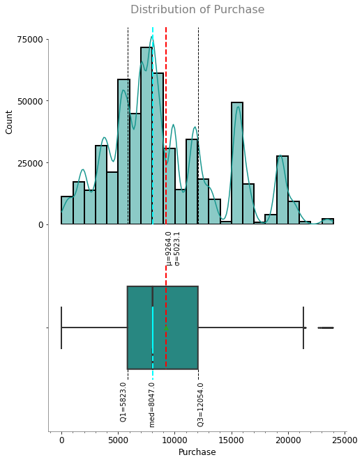

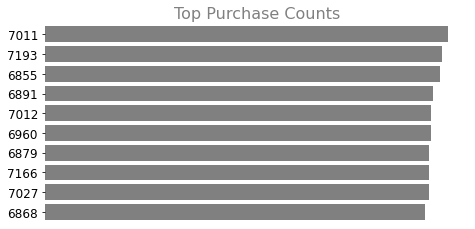

```python
plot_numeric_distribution(df_=df, var_='Purchase', main_title='Products Count per Age Years', xlablel_='Purchase in $', title_='Top Purchase Counts', box_major=5000, box_minor=1000)
```

**Insights**:

- The average purchase amount per transaction was \$9,264 with standard deviation of \$5,023.
- The median purchase amount was $8,047.
- There is a wide variation in the purchase amounts per transaction.
- There are few potential outliers.
- Majority (50%) of purchase amount per transaction was between \$5,823 to \$12,054.

## Gender

CI: 95%, number of samples = 10,000

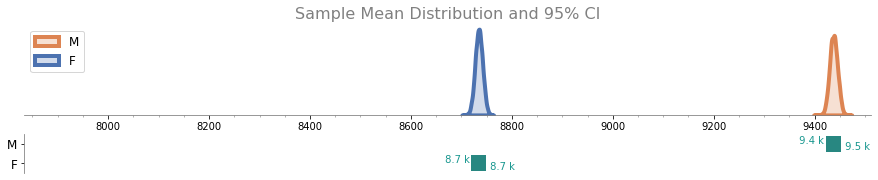

```
Average Purchase range in $ with 95% CI
```

| Category | From | To |
| --- | --- | --- |
| M | 9422.14 | 9452.99 |
| F | 8719.98 | 8749.15 |

```python
get_bootstrap_CI_and_Plot(df_=df, var_='Gender', summary_var_='Purchase', confidence_level=95, sample_size=None, num_repitions=None)
```

[output not shown]

CI: 95%, number of samples = 1,000

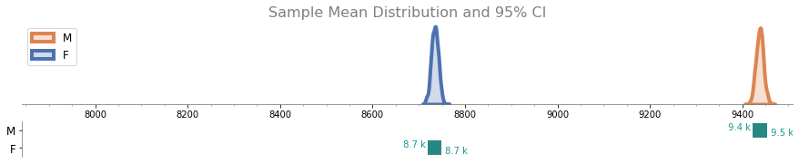

```
Average Purchase range in $ with 95% CI
```

| Category | From | To |
| --- | --- | --- |
| M | 9421.81 | 9453.20 |
| F | 8719.83 | 8749.29 |

```python
get_bootstrap_CI_and_Plot(df_=df, var_='Gender', summary_var_='Purchase', confidence_level=95, sample_size=None, num_repitions=1000)
```

CI: 95%, number of samples = 100

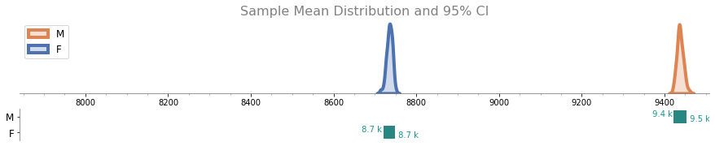

```
Average Purchase range in $ with 95% CI
```

| Category | From | To |
| --- | --- | --- |
| M | 9422.40 | 9452.56 |
| F | 8721.15 | 8748.57 |

```python
get_bootstrap_CI_and_Plot(df_=df, var_='Gender', summary_var_='Purchase', confidence_level=95, sample_size=None, num_repitions=100)
```

We observed minor variations in the confidence interval when we varied the number of samples from 10,000 to 1,000 and then to 100.

**Insights**:

- Although Walmart has equal numbers of male and female customers, male customers purchased more (~75%) than female customers (~25%)
- As a result, male customers spent more (~76%) than female customers (~24%)
- In general, male customers spend an average of \$9,422 to \$9,453. Female customers, on the other hand, spend between \$8,720 and \$8,750 on average.

**Recommendation**:

- The company should plan a loyalty program and marketing campaign for female customers
- The company should identify and introduce new products for female customers, initially with some discounts.

## Age

CI: 95%, number of samples = 10,000

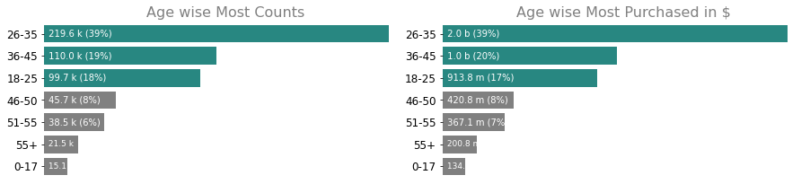

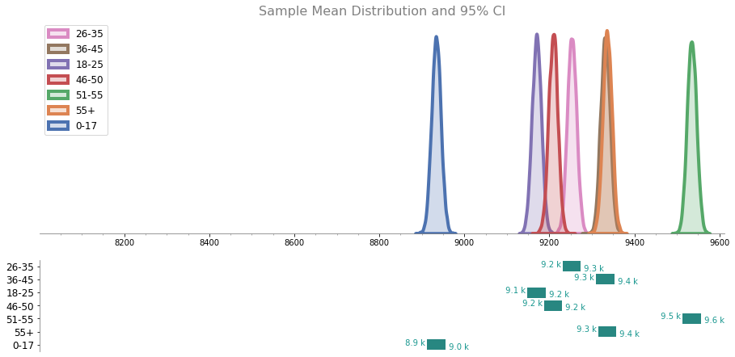

```
Average Purchase range in $ with 95% CI
```

| Category | From | To |
| --- | --- | --- |
| 26-35 | 9231.57 | 9273.84 |
| 36-45 | 9310.11 | 9352.47 |
| 18-25 | 9148.48 | 9190.94 |
| 46-50 | 9187.66 | 9229.47 |
| 51-55 | 9513.56 | 9556.27 |
| 55+ | 9315.53 | 9357.05 |
| 0-17 | 8912.05 | 8954.93 |

```python
get_bootstrap_CI_and_Plot(df_=df, var_='Age', summary_var_='Purchase', confidence_level=95, sample_size=None, num_repitions=None)
```

CI: 95%, number of samples = 1,000

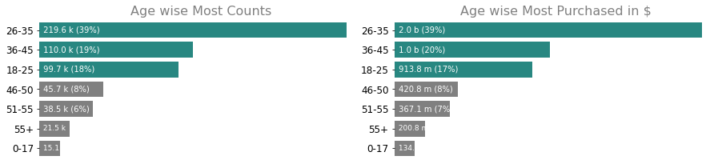

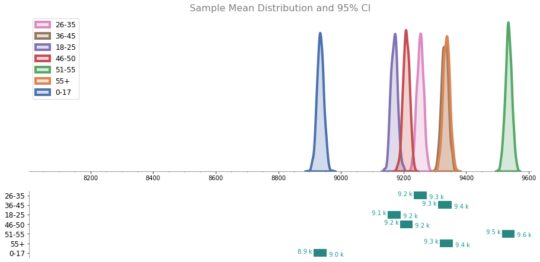

```
Average Purchase range in $ with 95% CI
```

| Category | From | To |
| --- | --- | --- |
| 26-35 | 9231.57 | 9273.43 |
| 36-45 | 9310.46 | 9352.79 |
| 18-25 | 9148.97 | 9189.93 |
| 46-50 | 9187.99 | 9228.27 |
| 51-55 | 9514.37 | 9555.17 |
| 55+ | 9315.63 | 9357.59 |
| 0-17 | 8912.40 | 8954.96 |

```python
get_bootstrap_CI_and_Plot(df_=df, var_='Age', summary_var_='Purchase', confidence_level=95, sample_size=None, num_repitions=1000)
```

We observed minor variations in the confidence interval when we varied the number of samples from 10,000 to 1,000.

**Insights**:

- Customers in the 26-35 age group purchased the most (~39%), followed by 36-45 (~19%) and 18-25 (~18%), and accordingly the proportion of the amount spent is similar.
- In general, customers younger than 17 spend the least (between \$8,912 and \$8,955). In contrast, customers between the ages of 51 and 55 spend the most on average (between \$9,513 and \$9,556). The rest of the customers spend, on average between \$9,100 and \$9,400.

**Recommendation**:

- The company should avoid to introduce expensive products for teenagers.

## Marital Status

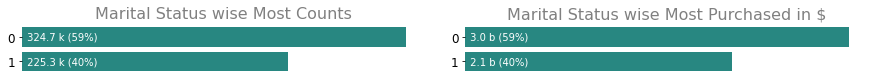

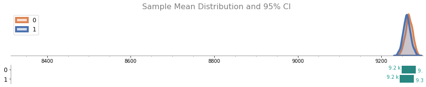

```
Average Purchase range in $ with 95% CI
```

| Category | From | To |
| --- | --- | --- |
| 0 | 9248.95 | 9282.93 |
| 1 | 9243.57 | 9278.07 |

```python
get_bootstrap_CI_and_Plot(df_=df, var_='Marital_Status', summary_var_='Purchase', confidence_level=95, sample_size=None, num_repitions=1000)
```

**Insights**:

- Customers with marital status 0 purchased more (~60%) than customers with marital status 1 (~40%) and accordingly the proportion of the amount spent is similar.
- In general, there is not much difference in spending behaviour between the two groups.

**Recommendation**:

- The company should plan more products to satisfy the needs of the group with marital status 0.

## Occupation

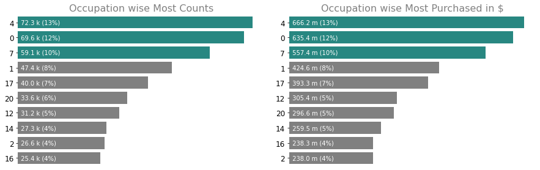

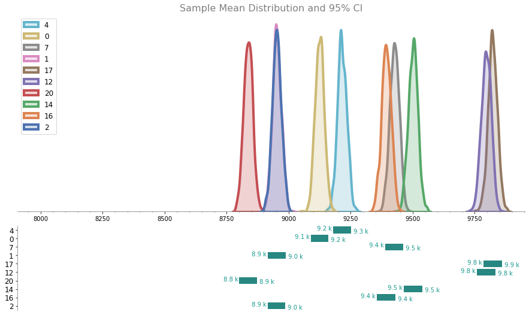

```
Average Purchase range in $ with 95% CI
```

| Category | From | To |
| --- | --- | --- |
| 4 | 9178.14 | 9251.66 |
| 0 | 9088.60 | 9159.77 |
| 7 | 9389.61 | 9462.68 |
| 1 | 8916.48 | 8987.55 |
| 17 | 9784.61 | 9858.83 |
| 12 | 9757.49 | 9834.02 |
| 20 | 8800.81 | 8871.59 |
| 14 | 9463.45 | 9538.20 |
| 16 | 9356.06 | 9430.28 |
| 2 | 8916.56 | 8986.95 |

```python
get_bootstrap_CI_and_Plot(df_=df, var_='Occupation', summary_var_='Purchase', confidence_level=95, sample_size=None, num_repitions=1000)
```

**Insights**:

- Customers in occupational category 4 purchased the most (~13%), followed by category 0 (~12%) and 7 (~10%), and accordingly the proportion of the amount spent is similar.
- In general, customers in occupational categories 17 and 12 on average spend the most on average (between \$9,760 and \$9,858). Customers with occupation category 1, 20, and 2 spend the least on average (between \$8,800 and \$9,000). The rest of the customers spend between \$9,000 and \$9,500.

**Recommendation**:

- The company should offer credit to customers with occupation category 1, 20, and 2 to increase their purchasing power.

## City Category

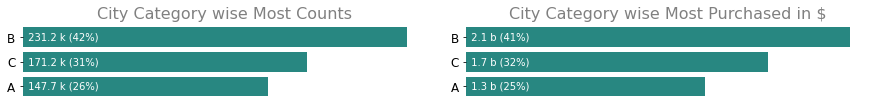

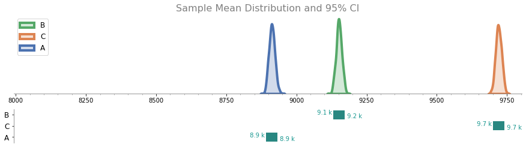

```
Average Purchase range in $ with 95% CI
```

| Category | From | To |
| --- | --- | --- |
| B | 9131.81 | 9171.31 |
| C | 9700.23 | 9741.00 |
| A | 8892.04 | 8933.17 |

```python
get_bootstrap_CI_and_Plot(df_=df, var_='City_Category', summary_var_='Purchase', confidence_level=95, sample_size=None, num_repitions=1000)
```

**Insights**:

- City category B customers purchased the most (~42%), followed by city category C (~31%) and A (~26%) customers, and accordingly the proportion of the amount spent is similar.
- In general, City Category C customers spend the most on average (between \$9,700 and \$9,741). City category A customers spend the least on average (between \$8,892 and \$8,933). While the customers in city category B spend the moderate on average (between \$9,131 and \$9,171).

**Recommendation**:

- The company should focus on improving the customer base in city category C, as customers from these cities spend more on average.

## Stay in Current City in Years

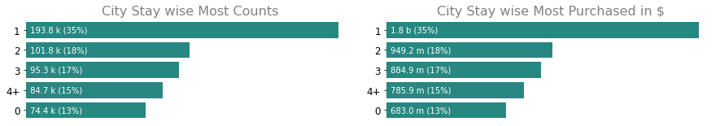

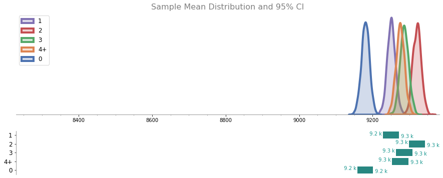

```
Average Purchase range in $ with 95% CI
```

| Category | From | To |
| --- | --- | --- |
| 1 | 9228.76 | 9272.30 |
| 2 | 9298.53 | 9342.65 |
| 3 | 9263.54 | 9309.07 |
| 4+ | 9252.61 | 9297.73 |
| 0 | 9158.69 | 9201.61 |

```python
get_bootstrap_CI_and_Plot(df_=df, var_='City_Stay', summary_var_='Purchase', confidence_level=95, sample_size=None, num_repitions=1000)
```

**Insights**:

- Customers who have been in the current city for about 1 year purchased the most (~35%), followed by 2 years (~18%) and 3 years (~17%), and accordingly the proportion of the amount spent is similar.
- In general, customers who have lived in the current city for about 2 years spend the most on average (between \$9,298 and \$9,342). In contrast, customers who are new to the city (less than 1 year of residence) spend the least on average (between \$9,158 and \$9,201). However, the difference is not very large.

**Recommendation**:

- The company should introduce promotional offers or subscriptions for new customers.

## Product Category

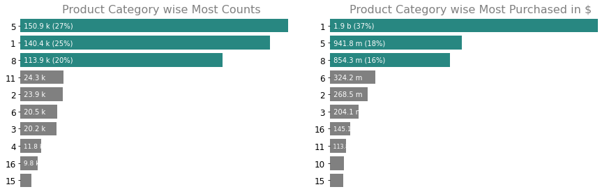

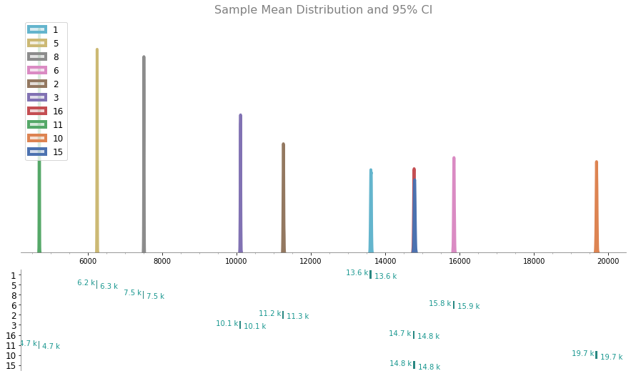

```
Average Purchase range in $ with 95% CI
```

| Category | From | To |
| --- | --- | --- |
| 1 | 13583.78 | 13628.59 |
| 5 | 6229.88 | 6250.26 |
| 8 | 7488.15 | 7509.73 |
| 6 | 15817.53 | 15860.04 |
| 2 | 11233.47 | 11270.27 |
| 3 | 10082.14 | 10110.87 |
| 16 | 14742.76 | 14789.19 |
| 11 | 4676.20 | 4694.78 |
| 10 | 19652.58 | 19698.22 |
| 15 | 14753.37 | 14807.74 |

```python
get_bootstrap_CI_and_Plot(df_=df, var_='Product_Category', summary_var_='Purchase', confidence_level=95, sample_size=None, num_repitions=1000)
```

**Recommendation**:

- The company should provide discounts for product category 1 to further increase its sales.

# Business Recommendations

- The company should plan a loyalty program and marketing campaign for female customers. The company should identify and introduce new products for female customers, initially with some discounts.
- The company should focus on improving the customer base in city category C, as customers from these cities spend more on average.
- The company should offer credit to customers with occupation category 1, 20, and 2 to increase their purchasing power.
- The company should provide discounts for product category 1 to further increase its sales.
- The company should plan more products to satisfy the needs of the group with marital status 0.
- The company should introduce promotional offers or subscriptions for new customers.
- The company should avoid to introduce expensive products for teenagers.